# NBA Manipulation

Sam Eckhardt and Joey Miranda

Tuesday, October 21, 2014

We were provided with multiple, very large and expansive data sets from Mr. Alex Bresler on various areas of the NBA including salary commitments, player information, and draft class history. Using these data sets we analyzed them and made graphs based on what information we wanted to derive.

First, we took the csv file nba_salary_commitments_14_2020 that has information on every player currently signed to an NBA team up to 2020, with how much money they are getting paid each year remaining on their contract. We decided to first look at each team individually and see how much money they have commited to paying their players over the next five years. With this graph you get a good sense of each teams salary budget and are able to compare teams salaries against each other. Using prior knowledge with NBA teams success (or failure) you can see if salary level can relate or be a causation of to success. Although this is not the case since the previous champions, the San Antonio Spurs, exist in the middle of the pack in terms of s salary, and the higher salary teams, like the New York Knicks and Brooklyn Nets, have not have much success over the last few years except for a few post season appearences. While a post season appearance is considered successful, you would expect having one of the highest salaries would atleast get you close to the championships. Since we cannot draw that conclusion, we could assume the reason for those teams to have high salaries are because they are large market teams, markets like the New York area or LA have a lot of fans which means having a star player or players can increase ticket sales which means more money for those teams.

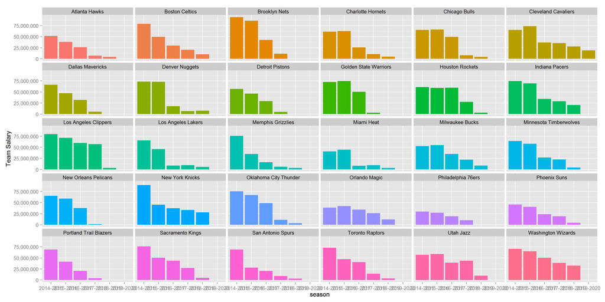

Using the same dataset as before we figured it would be interesting to see who the top three highest played players on each team and how much they are getting paid for the current 2014-2015 season. This is useful for locating NBA “superstars” and see how they measure up fiscally against other top players on the same team and other teams around the league. Although the last graph did a better job of this, with this graph you can also draw an understanding of a teams general salary range based on their top paid players and determine if their salary correlates to team success or overall market size.

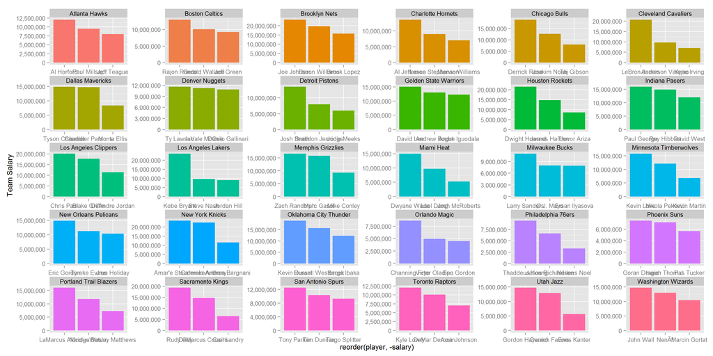

We then used the dataset NBA Draft History which had expansive information on each player in each draft class dating back to 1957. First we took that information and wanted to find out the average height of the player for each pick within the first round. We made the assumption that usually the first pick in the draft is usually tallest or taller than most other draft picks since very tall players are not easy to come by. And then as the draft continues with each pick it slowly decreases in the players height.

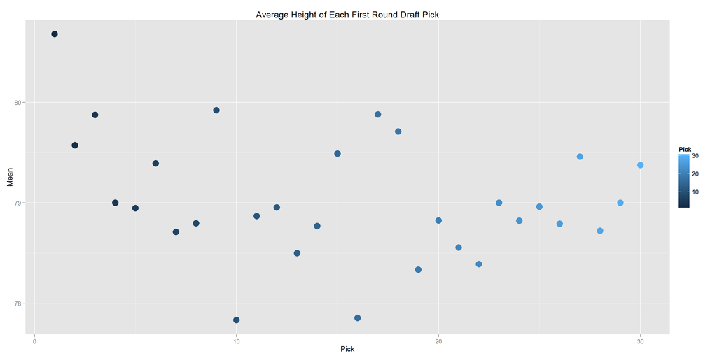

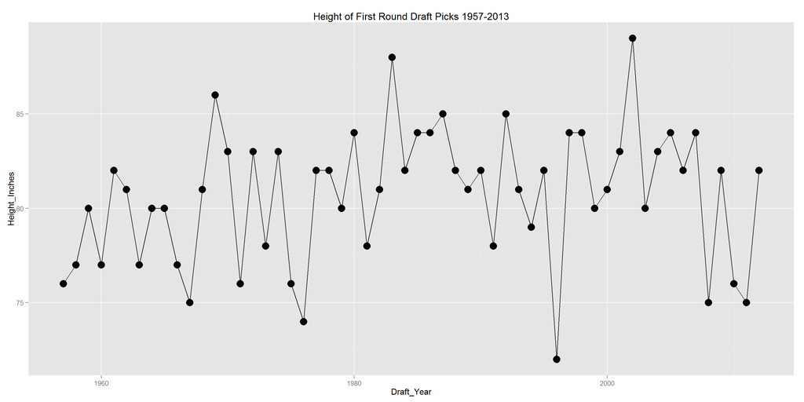

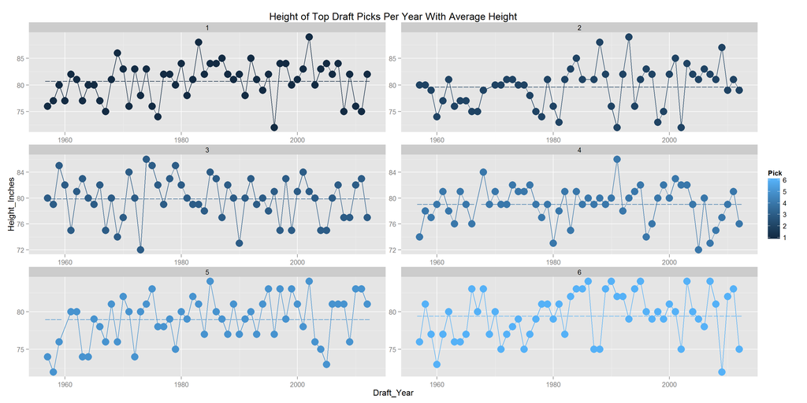

Next we took the entire class of actually drafted players and wanted to look how which schools those players came from, from the first and second round. We went in assuming we would see the big name, successful schools would appear in the top like Duke and Kentuckey, but we were not sure the order or even who is the top school. Using this graph you get a sense of which schools consistantly produce NBA quality players. Please note that on both graphs the top school listed as “I” is not a school at all but players that come from either straight out of school (which is no longer allowed) or players that come from out of the country aka international players.

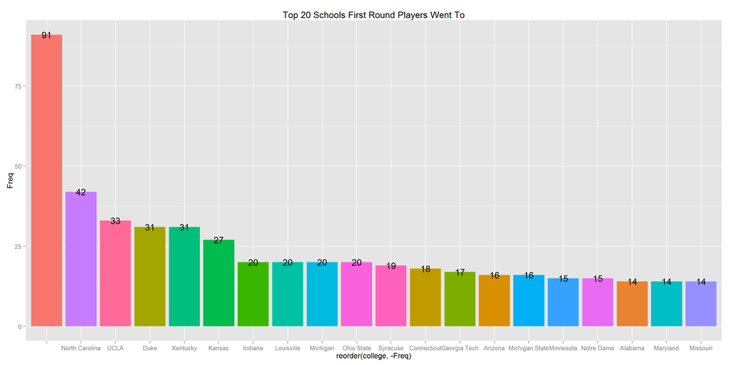

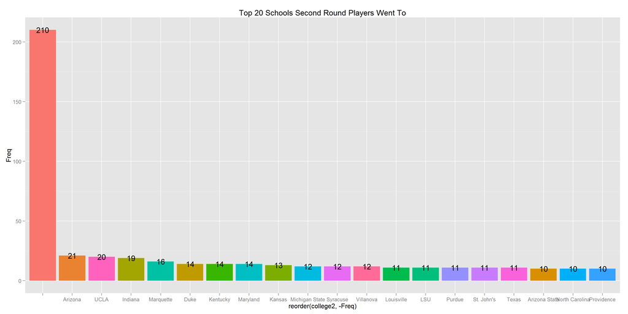